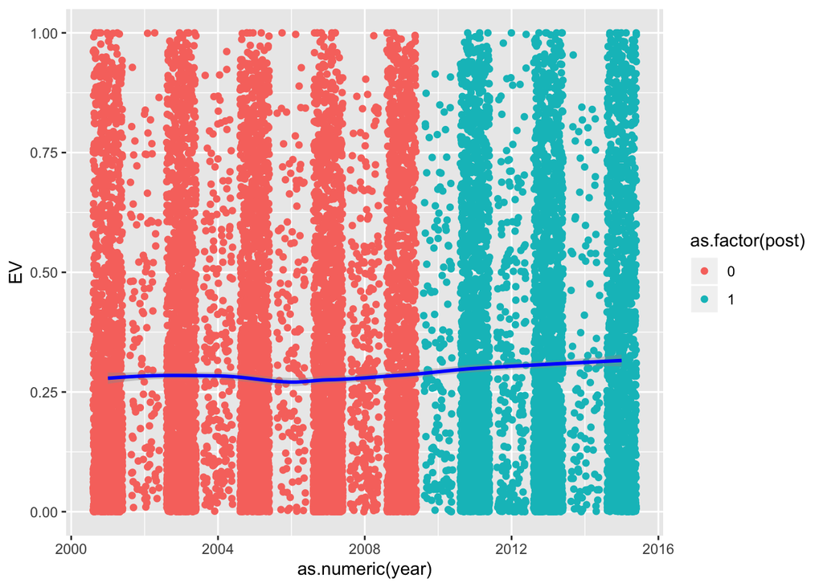

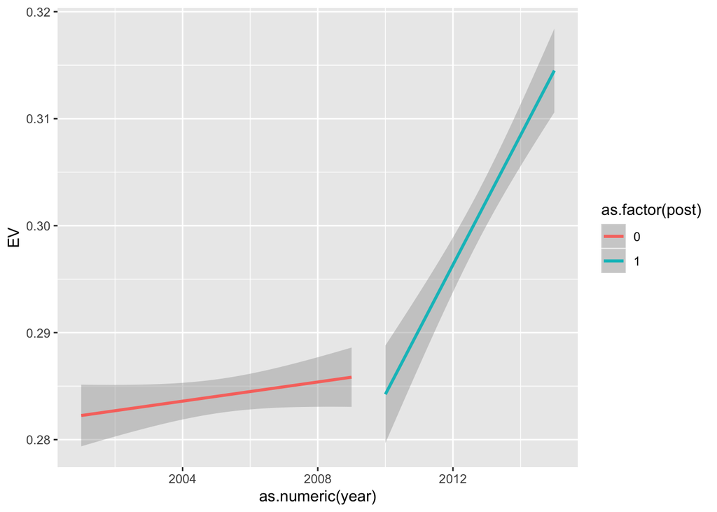

# Motivation. Motivate the research question (with at least a few references to previous research in the area). 2-4 paragraphs.

# Data. Describe the dataset, choose and describe one outcome, one treatment variable,

confounders and temporality. Also describe the sampling and sample size. About 1 page, possibly slightly

# Estimands. Define the notation and estimands (both with words and formulas) and

explain why they were chosen for this particular analysis (best fit to the research question, only estimand that the given method/data will support, etc). 1 paragraph on notation; 1-2 paragraphs per estimand.

In this project, what we are interested in is the average treatment effect (ATE) of the 2010 SCOTUS decision on political donors’ influence in their network. This can be shown in formula

$E[Y(1)-Y(0)]$

We choose this as our estimand because it is the estimand best fit for our project. Although the 2010 SCOTUS decision will likely only impact certain donors who have the willingness and ability to donate more than the previously stipulated $2500 amount, those high-donors changing patterns of donation will impact the position and attributes of the entire donation network. Therefore it does not make a lot of sense to only look at the average treatment for only treatment or only control group.

# Methods. Describe the 2 methods that will be used to estimate this quantity.

Describe each method as if to somehow who has never heard of it. Therefore include descriptions of all parts of the process (e.g. for pscore matching, how the pscore is estimated, how the matches/weights are formed, how the matches weights are used to estimate treatment effects, etc). Methods can include any of the methods discussed in the observational studies part of the course or extensions thereof (other methods will be considered but require prior approval). Methods cannot include linear regression. 1-2 pages.

## Method One: Regression Discontinuity

The first method we use to estimate our estimand is called regression discontinuity. Regression discontinuity a special case of an observational study design in which whether a unit receives treatment is decided solely based on values of one variable, usually referred to as the running variable. In this setting, there is a cutoff point on the running variable, where on one side all units receive the threatment and units on the other side do not. In a regression discontinuity model, it is usually assumed that the only confounding covariate is the running variable, given the appropriate bandwith around the cutoff point. Around the cutoff point, usually the units are considered randomly distributed so other confounding factors can be ignored. This method is appropriate for situations where researchers don’t have access to a lot of confounding covariate data.

In our project, the running variable is time, measured in year. And the cutoff point is at year 2010 when the Supreme Court Decision was made. We have set our bandwidth to be from 2009-2011. The reason for choosing our bandwidth is that 1) first, this is the smallest bandwidth that our dataset allows, and with this small bandwidth we have more confidence that donors in this time frame are more likely to be similarly/randomly distributed. 2) Second, since the running variable in our dataset is relatively “coarse”, meaning that year is really a large span of time. If we extend our bandwidth wider, then it would be unreasonable to assume the distribution of donors are still random across more than two years, with changing economical and political landscape.

We decide to use a linear model based on a preliminary plot, and based on the lowess curve the relationship between time and eigenvector centrality of campaign donors are linear than quadratic. So here in our regression discontinuity model we assume that their relationship is linear, except at the cutoff point.

In practice, we first restrict the model to the bandwidth, only considering the data points from years 2009 to 2011. We then create a variable to indicate the applicability of the Supreme Court decision, if before 2010 then 0 and otherwise 1. We fit the restristed dataset (from 2009 -2011) to a linear model, where the applicability indicator and year was used to predict the eigenvector centrality.

To answer our second question about potential partisan difference in the treatment effect, we divide our dataset to two parts for the regression discontinuity analysis. The first part is focused on the traditionally Republican donors, defined as those whose mean proportion of donation pre-2010 for Republican Congress members is larger than 60%. The second part is focused on the traditionally Democratic donors, defined as those whose mean proportion of donation pre-2010 for Democratic Congress members is larger than 60%. Focusing on the proportion of partisan donation pre-2010 helps us avoid controlling on post-treatment variables. With those two data sets we repeat the same process for regression discontinuity modeling as we did for the overall dataset.

## Method Two: Difference in Difference

Difference in Difference method is an observational method that mimics an experimental design, by taking the differential effect of a treatment on a treatment group and a control group. The way that DID estimates the treatment is by comparing the outcome change over time of both treatment and control groups. This method assumes that both treatment and control group’s outcome change similarly over time. Therefore, by taking the difference between treatment group outcome and control group temporal outcome change, this method can get can mitigate effects of extraneous factors.

In our project, we choose donors in the state of Vermont as our control group. Shortly after the SCOTUS decision, the U.S. District Court for the District of Vermont ruled in Vermont Right to Life Committee v. Sorrell (II) that Vermont’s contribution limits did apply to independent expenditure PACs, making Vermont somewhat free from the influence of the 2010 SCOTUS ruling.

Similar to our RDD model, here we also assume that the basic form of our model is linear, based on a preliminary observation our our data relationship.

In practice, we use all available years of our data. Similar to the RDD model, we also create a binary variable to indicate the applicability of the Supreme Court decision, if before 2010 then 0 and otherwise 1. We then create another binary variable to indicate whether a data point is in the treatment group or control group - if the donation happens in Vermont, then it is in control group, if not then it is in treatment group. Finally, we run an interation model, that uses treatment indicator, applicability indicator and their interaction term as predictor and the eigenvector centrality as outcome. The coefficient of the interaction term is the estimate we are looking for.

To answer our second question about potential partisan difference in the treatment effect, we fit a different model adding in variable to indicate the partisanship of the donor, defined in the same way as we did in the regression discontinuity model. We then run a similar difference in difference model, keeping all other predictors the same while only adding this partisan variable. We also run an anova test to see if adding the partisanship variable contributes to our model.

# Assumptions. Define the assumptions required for each method to identify a causal

effect and discuss their plausibility in the given setting. Several paragraphs.

## Method One: Regression Discontinuity

### First assumption: Randomization

The first assumption about regression discontinuity is that the treatment assignment is ignorable given X in a narrow interval of X around the cutoff. This means that we assume that data points are randomly distributed around the cutoff point, therefore other confounding factors can be ignored.

In our case, the randomization assumption is plausible because we set our bandwidth narrow enough (as narrow as possible). From 2009-2011, in the political campaign donation nothing major happened except our treatment variable. It is reasonable to assume that the bigger economic and political conditions are relatively stable.

### Second Assumption: Parametric form

The second assumption we are making here is that data on both sides of the cutoff follow a linear relationship with the running variable. This assumption is much tougher to say, since from the scatter plot we can see that the distribution of the data points are rather regular, and it seems like they don’t follow a clear parametric relationship. However, since our bandwidth is small, it is also more likely that the parametric assumption holds.

### Third Assumption: Bandwidth

The third assumption we made here is going with the small bandwidth we chose. We think that choosing this bandwidth makes sense because a smaller bandwidth helps our first and second assumption more plausible. Even though the generalizability of our finding might suffer a bit, from a theoretical persepctive, it is important we don’t over generalize. For example, if we go back to 2007 or 2008, we suffer from possible strong bias from confounding factors such as the 2008 Great Recession, or a different political administration in 2007.

## Method Two: Difference in Difference

To identify Average Treatment Effect (ATE), we need the difference of both treatment and control group to be independent of treatment assignment, and that we need to have the treatment group to look like the control group. Colloquially, this is also known as the parallel trend assumption.

In our case, this assumption is a bit questionable. Because we use only Vermont as our control group, it really isn’t that reliable. Being the home state of Bernie Sanders, Vermont has a very disctinct political culture and legal system that fosters its lack of SuperPac forming, which is very different from many other states in the treatment group. Other indicators such as economic development and party identification also makes Vermont not an equal counterpart to our treatment group states. It is likely that the D(1) of Vermont is different from those in the treatment group, and the D(0) of the treated is different from that of Vermont’s. But with the data we have, and how the 2010 SCOTUS decision is so sweeping across states, Vermont is our best bet.

# Diagnostics. Present and discuss diagnostics appropriate to each method (e.g. balance

tables or plots for propensity score analyses, regression diagnostics for methods that rely on linear models). Several paragraphs of text in addition to appropriate tables/plots. [Note that if you use two different propensity score methods you need to present separate diagnostics for each!]

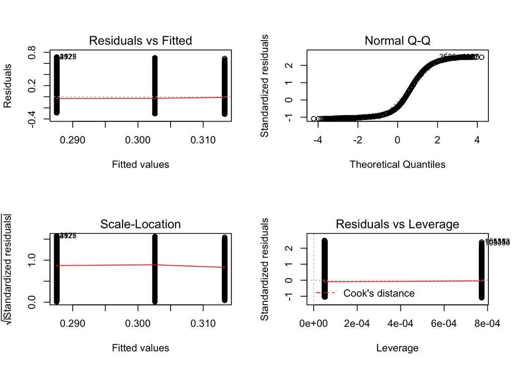

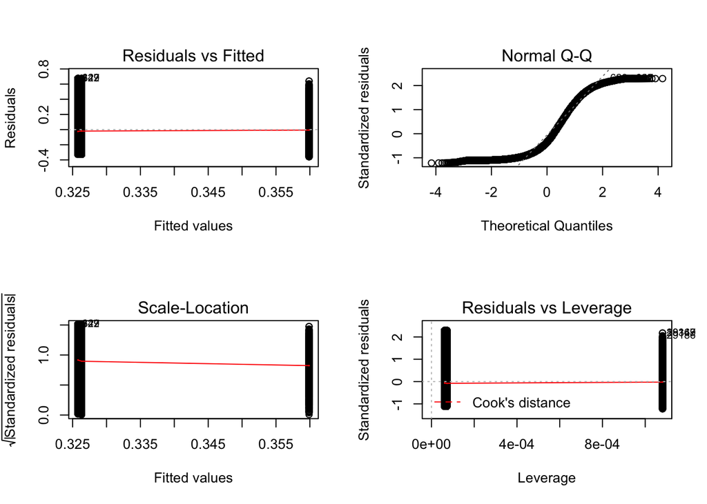

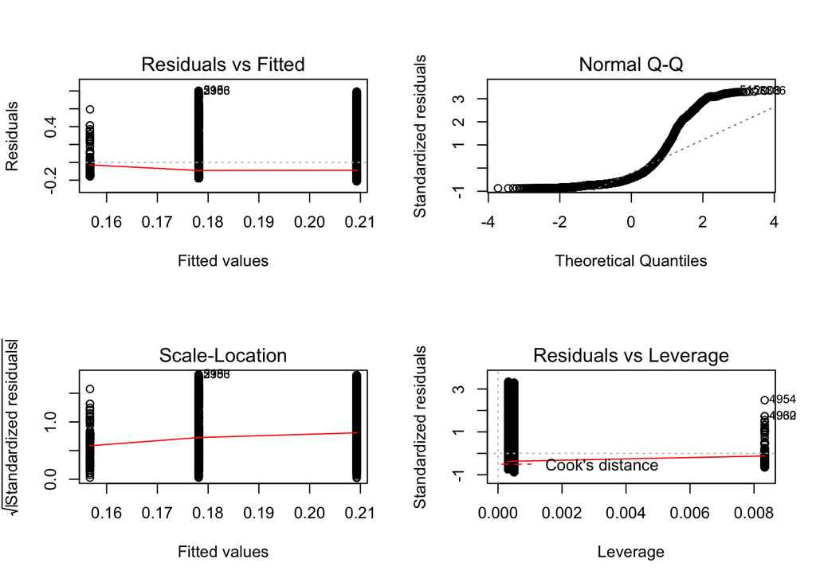

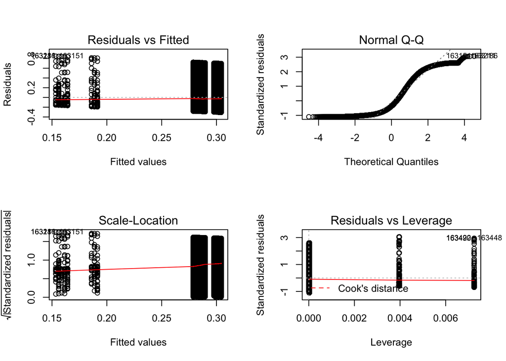

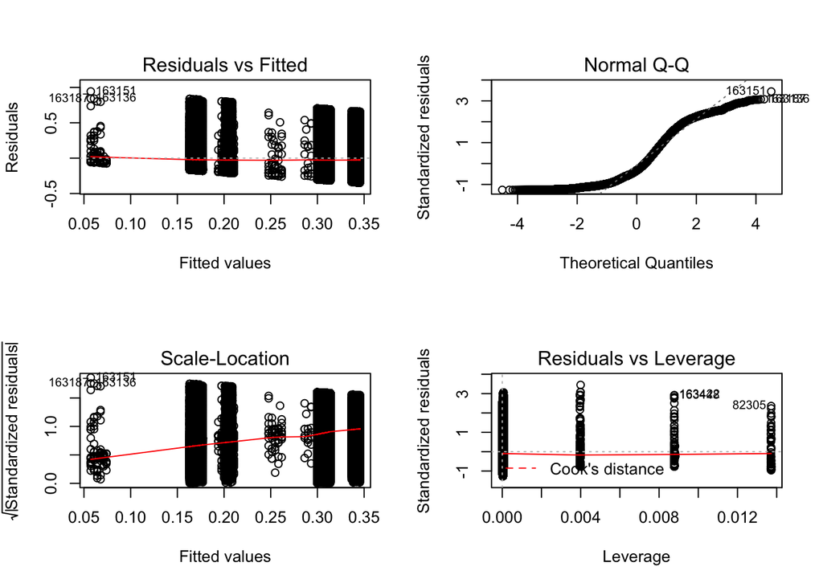

The results of the regression diagnostics are shown as above. For model one (basic RDD), we can see from the Residuals vs. Fitted graph that the linear parametric assumption seems right. The QQ plot shows that data at both ends do not have normally distributed, but most of the data points are. The the line in the Scale-Location figure is relatively straight, so it is relatively safe to say in our regression homoscedasticity holds relatively well. In the Residuals vs Leverage figure, we see some points have really high leverage and high influence, but none has extreme residuals (none with standard residual larger than 3).

For model 4 (basic DID), linear assumption holds. Data at both ends do not have normally distributed, but most of the data points are. Homoscedasticity still holds and there seem to be many fewer high leverage and high influence points, compared to basic RDD model. For model 5 (DID with previous party indicator as covariate), the story is very similar to model 4 except for homoscedasticity. From the Scale-Location graph, it seems that residuals are increasing with fitted values. So it is very likely this model is heteroscedasticitic.

# Results. Concisely present results and provide causal interpretations regardless of

statistical significance. 2-4 paragraphs. In addition to the results from your analysis always include vanilla linear regression estimates as a point of comparison.

```
##
## Regression Results
## ==========================================================================
##                                   Dependent variable:
##              -------------------------------------------------------------
##                                           EV
##                 RDD    RDD.Rep   RDD.Dem    DID    DID.party LinRegression
##                 (1)      (2)       (3)      (4)       (5)         (6)
## --------------------------------------------------------------------------
## treated                                   0.125*** 0.106***
##                                           (0.017)   (0.017)
##
## trans_yr     -0.026*** 0.053**  -0.034*** 0.001*** 0.002***    0.001***
##               (0.008)  (0.023)   (0.010)  (0.0003) (0.0003)    (0.0003)
##
## partyNone                                           -0.052
##                                                     (0.032)
##
## partyRep                                           -0.137***
##                                                     (0.002)
##
## treated:post                               -0.013    0.029
##                                           (0.029)   (0.031)
##
## post          0.036**  -0.074*  0.068***   0.019    -0.008     0.007***
##               (0.016)  (0.044)   (0.020)  (0.029)   (0.031)     (0.003)
##
## Constant     0.277***  0.231*** 0.292***  0.165*** 0.210***    0.291***
##               (0.009)  (0.023)   (0.010)  (0.017)   (0.017)     (0.002)
##
## --------------------------------------------------------------------------
## Observations  40,849    5,215    31,130   172,368   156,880     172,368
## R2             0.001    0.004    0.0004    0.001     0.036       0.001
## Adjusted R2    0.001    0.004    0.0003    0.001     0.036       0.001
## ==========================================================================
## Note:                                          *p<0.1; **p<0.05; ***p<0.01
```

As can be seen from the regression table, the estimates of ATE are all coefficient of the binary indicator of pre/post 2010 variable, except for the DID model, in which the iteraction term between the treatment variable and the pre/post-2010 indicator is the estimator.

The effectiveness of the RDD model can be seen in comparison with the final vanilla linear regression model. The final model still shows a positive effect of the treatment, yet the estimate is much smaller. It makes sense because RDD narrows in on the period of treatment and can get a better grasp of the effect of treatment, instead of looking at all data globally.

# Discussion. Discuss the results and the limitations of the analyses. 3-4 paragraphs.